# Analiza kriminala i socio-ekonomskih faktora

Bruno Ćorić, Filip Škrlec, Jelena Matečić, Iva Zekić

11/6/2020

## Učitavanje podataka

Imamo dva skupa podataka kriminala i socio-ekonomskih faktora za grad Chicago.

```r
crimeDataset <- read.csv("crime_datasets/Crimes_-_One_year_prior_to_present.csv"
                         ,stringsAsFactors = F,na.strings = "")

povertyDataset <- read.csv("crime_datasets/Chicago_poverty_and_crime.csv"
                           ,stringsAsFactors = F, na.strings="")

head(crimeDataset)
```

|  | CASE. | DATE..OF.OCCURRENCE | BLOCK | IUCR | PRIMARY.DESCRIPTION | SECONDARY.DESCRIPTION | LOCATION.DESCRIPTION | ARREST | DOMESTIC | BEAT | WARD | FBI.CD | X.COORDINATE | Y.COORDINATE | LATITUDE | LONGITUDE | LOCATION |
| --- | --- | --- | --- | --- | --- | --- | --- | --- | --- | --- | --- | --- | --- | --- | --- | --- | --- |
| 1 | JD388829 | 10/04/2020 08:31:00 PM | 086XX S CARPENTER ST | 0560 | ASSAULT | SIMPLE | APARTMENT | N | N | 613 | 21 | 08A | 1170827 | 1847522 | 41.73707 | -87.64972 | (41.737074199, -87.64972468) |
| 2 | JD346990 | 08/26/2020 01:33:00 PM | 011XX N DEARBORN ST | 0890 | THEFT | FROM BUILDING | APARTMENT | N | N | 1824 | 2 | 06 | NA | NA | NA | NA | NA |
| 3 | JD403530 | 10/18/2020 03:50:00 PM | 049XX W ADAMS ST | 0460 | BATTERY | SIMPLE | STREET | N | N | 1533 | 28 | 08B | NA | NA | NA | NA | NA |
| 4 | JD141525 | 02/05/2020 02:54:00 PM | 030XX N HALSTED ST | 0860 | THEFT | RETAIL THEFT | DRUG STORE | N | N | 1933 | 44 | 06 | NA | NA | NA | NA | NA |
| 5 | JD366829 | 08/26/2020 02:19:00 AM | 021XX W CULLERTON ST | 0890 | THEFT | FROM BUILDING | APARTMENT | N | N | 1234 | 25 | 06 | NA | NA | NA | NA | NA |
| 6 | JD205528 | 04/09/2020 02:00:00 PM | 029XX S ARCHER AVE | 1320 | CRIMINAL DAMAGE | TO VEHICLE | STREET | N | N | 913 | 11 | 14 | 1168260 | 1885596 | 41.84161 | -87.65803 | (41.841609341, -87.65803375) |

```r
head(povertyDataset)
```

|  | Community.Area | Community.Area.Name | Assault..Homicide. | Firearm.related | Below.Poverty.Level | Crowded.Housing | Dependency | No.High.School.Diploma | Per.Capita.Income | Unemployment |
| --- | --- | --- | --- | --- | --- | --- | --- | --- | --- | --- |
| 1 | 1 | Rogers Park | 7.7 | 5.2 | 22.7 | 7.9 | 28.8 | 18.1 | 23714 | 7.5 |
| 2 | 2 | West Ridge | 5.8 | 3.7 | 15.1 | 7.0 | 38.3 | 19.6 | 21375 | 7.9 |
| 3 | 3 | Uptown | 5.4 | 4.6 | 22.7 | 4.6 | 22.2 | 13.6 | 32355 | 7.7 |
| 4 | 4 | Lincoln Square | 5.0 | 6.1 | 9.5 | 3.1 | 25.6 | 12.5 | 35503 | 6.8 |
| 5 | 5 | North Center | 1.0 | 1.0 | 7.1 | 0.2 | 25.5 | 5.4 | 51615 | 4.5 |
| 6 | 6 | Lake View | 1.4 | 1.8 | 10.5 | 1.2 | 16.5 | 2.9 | 58227 | 4.7 |

Faktorizirat ćemo podatke koje bi bilo logično faktorizirati kao što su podaci u stupcu Arrest,Domestic.

```r
crimeDataset$ARREST <- as.factor(crimeDataset$ARREST)
crimeDataset$DOMESTIC <- as.factor(crimeDataset$DOMESTIC)
```

Provjeravamo fale li nam neki podaci u najbitnim kategorijama u oba dataseta.

```r
s <-c(1,2,3,4,5,6,8,9)
sum(is.na(crimeDataset[s]))
```

```
## [1] 0
```

```r
sum(is.na(povertyDataset))
```

```
## [1] 0
```

## Razlika učestalosti zločina ovisno o tome koje je doba dana

```r
timeOfTheDay <- mdy_hms(crimeDataset$DATE..OF.OCCURRENCE) %>% hour
timeOfTheDay <- sapply(timeOfTheDay, function(x) {
  if(x >= 5 & x < 13) {
    "morning"
  } else if(x >= 13 & x < 20) {
    "afternoon"
  } else {
    "evening"
  }
},simplify="vector")
timeOfTheDay <- as.factor(timeOfTheDay)
crimeDataset$TIME.OF.DAY <- timeOfTheDay
timeOfTheDayCount <- crimeDataset %>% group_by(TIME.OF.DAY) %>% tally
head(crimeDataset[c("DATE..OF.OCCURRENCE","TIME.OF.DAY")])
```

|  | DATE..OF.OCCURRENCE | TIME.OF.DAY |
| --- | --- | --- |
| 1 | 10/04/2020 08:31:00 PM | evening |
| 2 | 08/26/2020 01:33:00 PM | afternoon |
| 3 | 10/18/2020 03:50:00 PM | afternoon |
| 4 | 02/05/2020 02:54:00 PM | afternoon |
| 5 | 08/26/2020 02:19:00 AM | evening |
| 6 | 04/09/2020 02:00:00 PM | afternoon |

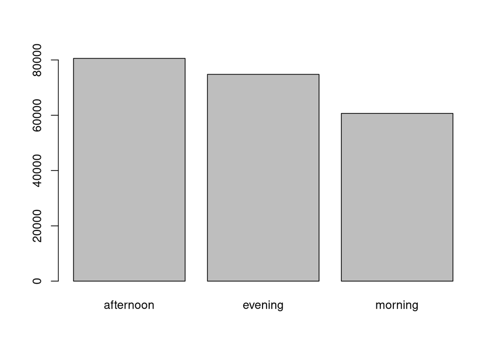

```r
barplot(table(crimeDataset$TIME.OF.DAY))
```

Napravit ćemo goodnes of fit test nad brojem kriminala koji se dogodio ujutro, popodne i navečer. Nulta hipoteza testa je da je očekivana proporcija 1/3 za broj kriminala u određenom dijelu dana, tj. da se ne razlikuje broj kriminala s obzirom na vrijeme.

```r
chisq.test(timeOfTheDayCount$n)
```

```
##
##  Chi-squared test for given probabilities
##
## data:  timeOfTheDayCount$n
## X-squared = 2909.8, df = 2, p-value < 2.2e-16
```

```r
as.factor(crimeDataset$PRIMARY.DESCRIPTION) %>% levels
```

```
##  [1] "ARSON"                             "ASSAULT"
##  [3] "BATTERY"                           "BURGLARY"
##  [5] "CONCEALED CARRY LICENSE VIOLATION" "CRIM SEXUAL ASSAULT"
##  [7] "CRIMINAL DAMAGE"                   "CRIMINAL SEXUAL ASSAULT"
##  [9] "CRIMINAL TRESPASS"                 "DECEPTIVE PRACTICE"
## [11] "GAMBLING"                          "HOMICIDE"
## [13] "HUMAN TRAFFICKING"                 "INTERFERENCE WITH PUBLIC OFFICER"
## [15] "INTIMIDATION"                      "KIDNAPPING"
## [17] "LIQUOR LAW VIOLATION"              "MOTOR VEHICLE THEFT"
## [19] "NARCOTICS"                         "NON-CRIMINAL"
## [21] "OBSCENITY"                         "OFFENSE INVOLVING CHILDREN"
## [23] "OTHER NARCOTIC VIOLATION"          "OTHER OFFENSE"
## [25] "PROSTITUTION"                      "PUBLIC INDECENCY"
## [27] "PUBLIC PEACE VIOLATION"            "ROBBERY"
## [29] "SEX OFFENSE"                       "STALKING"
## [31] "THEFT"                             "WEAPONS VIOLATION"
```

Odbacujemo nultu hipotezu i zaključujemo da da su proporcije različite.

Napravit ćemo test o homogenosti u kojem želimo viditi postoji li razlika u količini zločina s obzirom na doba dana.

Napravit ćemo test homogenosti u kojem ćemo provjeriti je li broj zločina opasnih po život jednak za sva 3 doba dana. Zločine koje smo uzeli da su opasni po život nalaze se u varijabli `dangCrimes`.

| dangerousCrimes | Freq |
| --- | --- |
| dangerous | 105252 |
| less dangerous | 110780 |

|  | dangerous | less dangerous |
| --- | --- | --- |
| afternoon | 36835 | 43736 |
| evening | 41162 | 33626 |
| morning | 27255 | 33418 |

```
##
##  Pearson's Chi-squared test
##
## data:  dangerous
## X-squared = 1836.2, df = 2, p-value < 2.2e-16
```

Zaključujemo da se razlikuje količina opasnih i neopasnih zločina ovisno o tome koje je doba dana.

## Je li učestalost krađa veća od učestalosti kriminala vezanih za narkotike?

Kreiramo novi dataset pod nazivom krada_narkotici u koji odvajamo samo one zločine koji su vezani uz krađu ili narkotike. Zločini vezani uz krađu su krađa automobila, krađa te pljačka, a zločini vezani uz narkotike su pod varijablom PRIMARY.DESCRIPTION imali ili naznaku “NARCOTICS” ili “OTHER NARCOTIC VIOLATION”.

```r
krada_narkotici = crimeDataset[which(crimeDataset$PRIMARY.DESCRIPTION == 'MOTOR VEHICLE THEFT' | crimeDataset$PRIMARY.DESCRIPTION == 'ROBBERY'| crimeDataset$PRIMARY.DESCRIPTION == 'THEFT' | crimeDataset$PRIMARY.DESCRIPTION == 'NARCOTICS' | crimeDataset$PRIMARY.DESCRIPTION == 'OTHER NARCOTIC VIOLATION'),]
head(krada_narkotici)
```

|  | CASE. | DATE..OF.OCCURRENCE | BLOCK | IUCR | PRIMARY.DESCRIPTION | SECONDARY.DESCRIPTION | LOCATION.DESCRIPTION | ARREST | DOMESTIC | BEAT | WARD | FBI.CD | X.COORDINATE | Y.COORDINATE | LATITUDE | LONGITUDE | LOCATION | TIME.OF.DAY |
| --- | --- | --- | --- | --- | --- | --- | --- | --- | --- | --- | --- | --- | --- | --- | --- | --- | --- | --- |
| 2 | JD346990 | 08/26/2020 01:33:00 PM | 011XX N DEARBORN ST | 0890 | THEFT | FROM BUILDING | APARTMENT | N | N | 1824 | 2 | 06 | NA | NA | NA | NA | NA | afternoon |
| 4 | JD141525 | 02/05/2020 02:54:00 PM | 030XX N HALSTED ST | 0860 | THEFT | RETAIL THEFT | DRUG STORE | N | N | 1933 | 44 | 06 | NA | NA | NA | NA | NA | afternoon |
| 5 | JD366829 | 08/26/2020 02:19:00 AM | 021XX W CULLERTON ST | 0890 | THEFT | FROM BUILDING | APARTMENT | N | N | 1234 | 25 | 06 | NA | NA | NA | NA | NA | evening |
| 8 | JC497784 | 11/03/2019 11:40:00 AM | 032XX N CLARK ST | 0860 | THEFT | RETAIL THEFT | DEPARTMENT STORE | N | N | 1924 | 44 | 06 | NA | NA | NA | NA | NA | morning |
| 9 | JD403673 | 10/18/2020 08:33:00 PM | 075XX N PAULINA ST | 031A | ROBBERY | ARMED - HANDGUN | CTA STATION | N | N | 2422 | 49 | 03 | NA | NA | NA | NA | NA | evening |
| 11 | JD362358 | 09/08/2020 07:00:00 PM | 050XX W ADAMS ST | 0910 | MOTOR VEHICLE THEFT | AUTOMOBILE | STREET | N | N | 1533 | 28 | 07 | 1143005 | 1898866 | 41.87853 | -87.75038 | (41.878531497, -87.750381613) | afternoon |

Nakon toga provjeravamo učestalost kriminala vezanih uz krađu i narkotike te vizualiziramo podatke barplot() funkcijom.

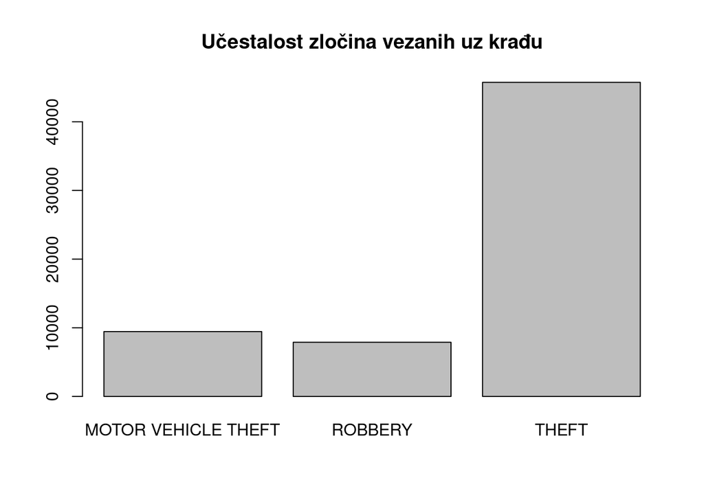

```r
description <- krada_narkotici$PRIMARY.DESCRIPTION
description <- as.data.frame(table(description))

krada <- description[which(description == 'MOTOR VEHICLE THEFT' |description =='ROBBERY' | description == 'THEFT' ),]
narkotici <- description[which(description == 'NARCOTICS' |description =='OTHER NARCOTIC VIOLATION'),]

barplot(krada$Freq,names.arg = c("MOTOR VEHICLE THEFT", "ROBBERY",'THEFT'),main = 'Učestalost zločina vezanih uz krađu')
```

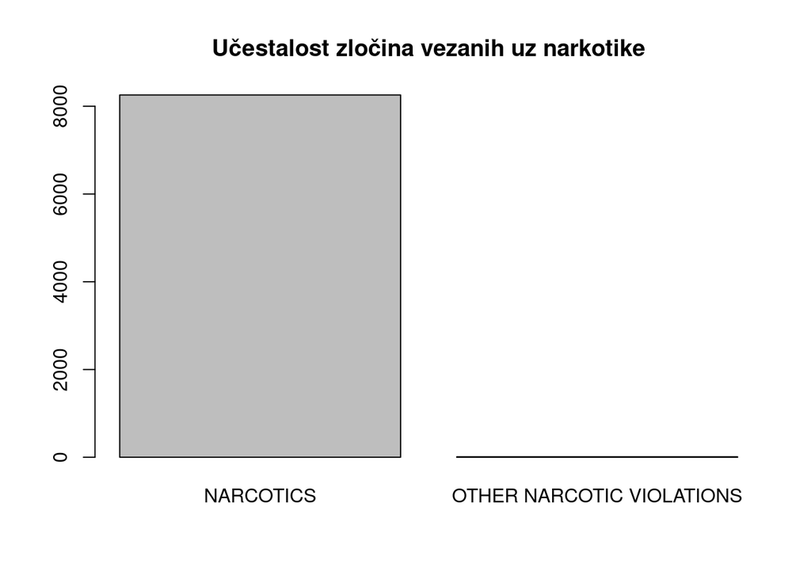

```r
barplot(narkotici$Freq,names.arg=c("NARCOTICS", "OTHER NARCOTIC VIOLATIONS"),main = 'Učestalost zločina vezanih uz narkotike')
```

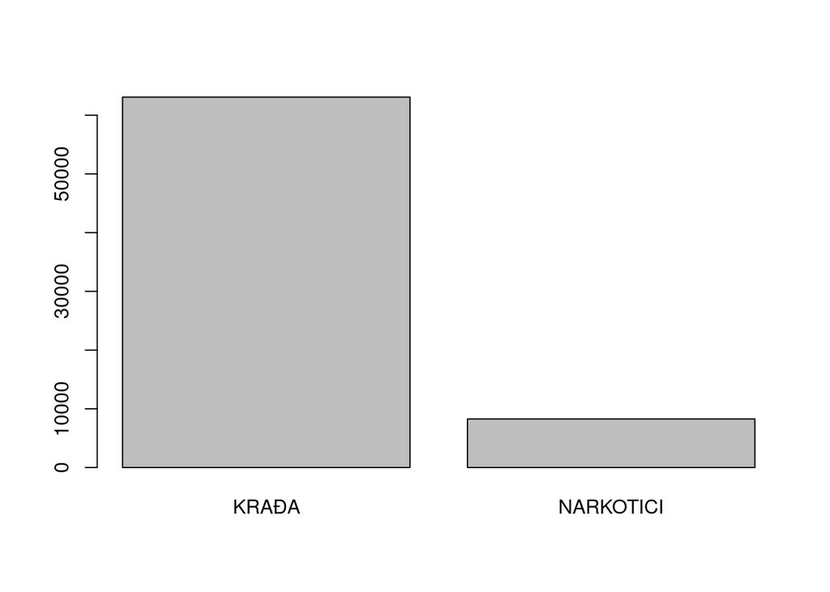

```r
barplot(c(sum(krada$Freq),sum(narkotici$Freq)), names.arg=c("KRAĐA", "NARKOTICI"))
```

```r
ukupno <- matrix(c(sum(krada$Freq), sum(narkotici$Freq)), ncol=2)

res <- prop.test(x = ukupno, n =sum(krada$Freq)+sum(narkotici$Freq),
p = 0.5, correct = FALSE,alternative = "two.sided")
res
```

```
##
##  1-sample proportions test without continuity correction
##
## data:  ukupno, null probability 0.5
## X-squared = 42111, df = 1, p-value < 2.2e-16
## alternative hypothesis: true p is not equal to 0.5
## 95 percent confidence interval:
##  0.8817529 0.8864501
## sample estimates:
##         p
## 0.8841222
```

Kako smo dobili jako mali p-vrijednost onda imamo dovoljno dokaza za odbacivanje nulte hipoteze u korist alternativne hipoteze. Zbog toga zaključujemo da je učestalost zločina povezanih s krađom znatno veća od učestalosti zločina povezanih s narkoticima.

## Veza između socio-ekonomskih faktora i pojedine kategorije kriminala

Ispitivati ćemo različite varijable koje bi mogle utjecati na “Assault Homicide” i “Firearm related” kategroije kriminala. Varijable koje ćemo promatrati su (postotci predstavljaju postotak broja stanovništva za određeni kvart): - postotak stanovništva koji su siromašni - postotak stanovništva koji žive u prenatrpanoj kući - postotak ljudi mlađih od 16 ili starijih od 64 koji su financijski ovisni o nekome - postotak ljudi bez diplome srednje škole - dohodak po stanovniku - postotak ljudi koji nisu zaposleni

Nacratat ćemo nekoliko grafova kako bi dobili uvid u to kakav odnos imaju varijable.

Vidimo linearan efekt kod nezaposlenosti i siromaštva. Dependency izgleda kao eksponencijalna funkcija dok Per Capita Income kao logaritamska.

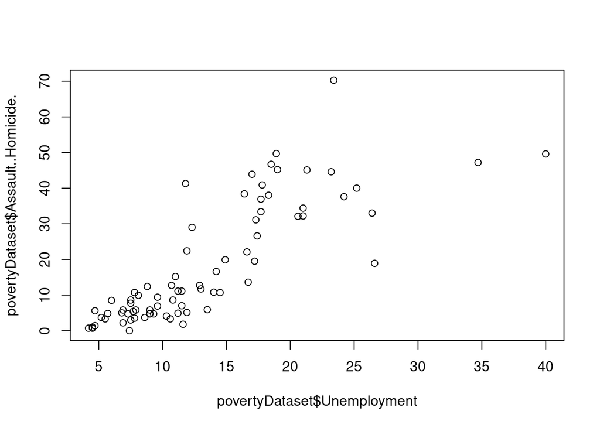

```r
plot(povertyDataset$Unemployment, povertyDataset$Assault..Homicide.)
```

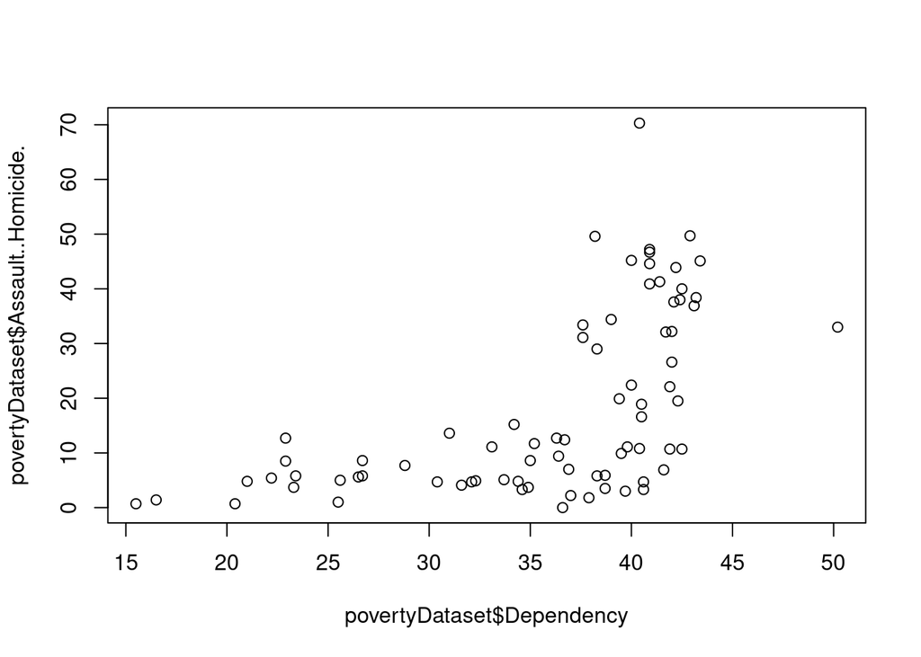

```r
plot(povertyDataset$Dependency, povertyDataset$Assault..Homicide.)
```

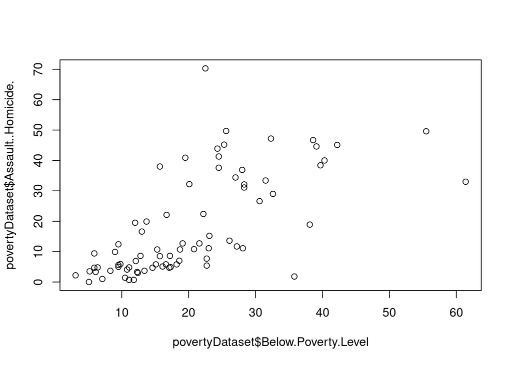

```r
plot(povertyDataset$Below.Poverty.Level, povertyDataset$Assault..Homicide.)
```

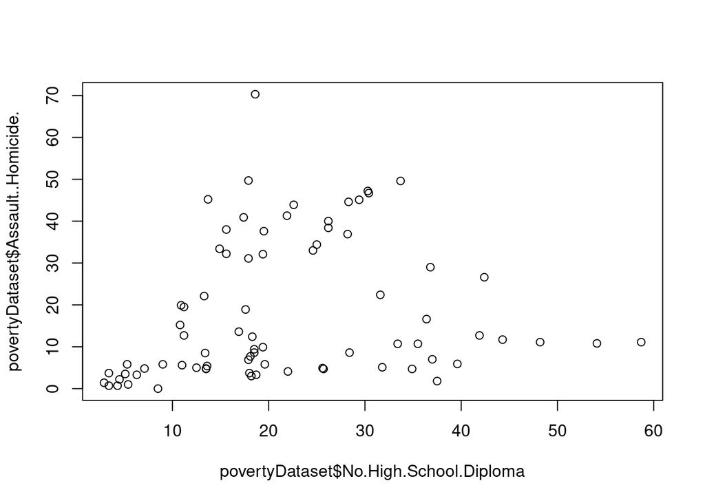

```r
plot(povertyDataset$No.High.School.Diploma, povertyDataset$Assault..Homicide.)
```

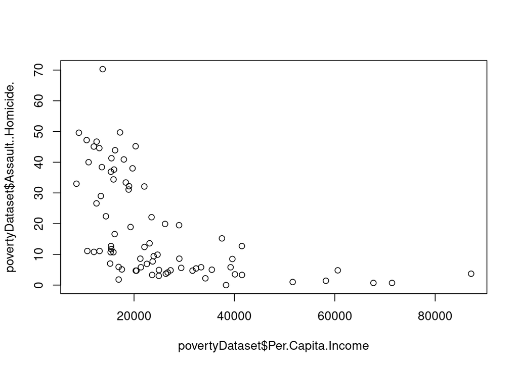

```r
plot(povertyDataset$Per.Capita.Income, povertyDataset$Assault..Homicide.)
```

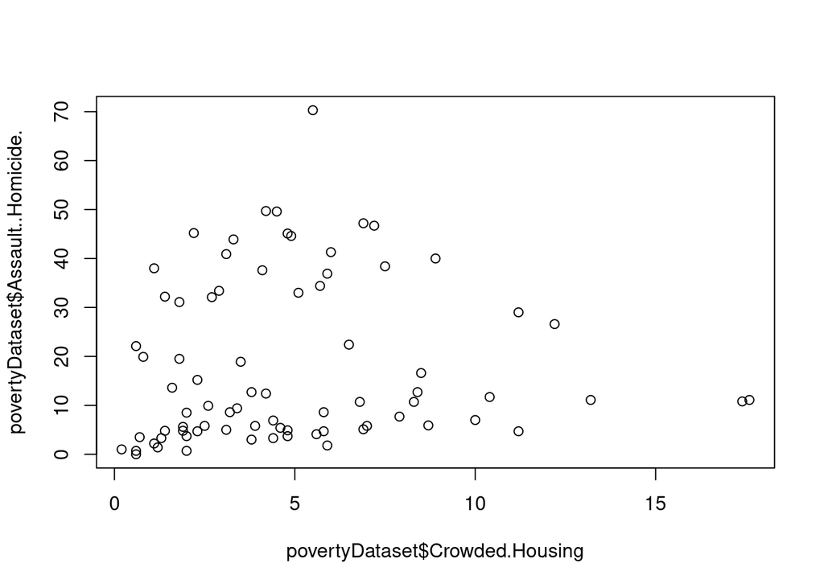

```r
plot(povertyDataset$Crowded.Housing, povertyDataset$Assault..Homicide.)
```

Neke varijable su jako korelirane. Što je i bilo za očekivati.

```r
cor(povertyDataset[c(-1,-2)])
```

```
##                        Assault..Homicide. Firearm.related Below.Poverty.Level
## Assault..Homicide.              1.0000000      0.96717019           0.6671429
## Firearm.related                 0.9671702      1.00000000           0.5657597
## Below.Poverty.Level             0.6671429      0.56575966           1.0000000
## Crowded.Housing                 0.0662508      0.03445091           0.3232420
## Dependency                      0.5748271      0.59079639           0.4013540
## No.High.School.Diploma          0.1822667      0.13125365           0.4223819
## Per.Capita.Income              -0.5327565     -0.49685919          -0.5265178
## Unemployment                    0.8148348      0.72257661           0.7638170
##                        Crowded.Housing Dependency No.High.School.Diploma
## Assault..Homicide.          0.06625080  0.5748271              0.1822667
## Firearm.related             0.03445091  0.5907964              0.1312537
## Below.Poverty.Level         0.32324204  0.4013540              0.4223819
## Crowded.Housing             1.00000000  0.2444501              0.9052740
## Dependency                  0.24445012  1.0000000              0.4243563
## No.High.School.Diploma      0.90527402  0.4243563              1.0000000
## Per.Capita.Income          -0.54520398 -0.7565786             -0.7073543
## Unemployment                0.14430444  0.6049994              0.3229021
##                        Per.Capita.Income Unemployment
## Assault..Homicide.            -0.5327565    0.8148348
## Firearm.related               -0.4968592    0.7225766
## Below.Poverty.Level           -0.5265178    0.7638170
## Crowded.Housing               -0.5452040    0.1443044
## Dependency                    -0.7565786    0.6049994
## No.High.School.Diploma        -0.7073543    0.3229021
## Per.Capita.Income              1.0000000   -0.6105529
## Unemployment                  -0.6105529    1.0000000
```

Izvdojimo neke više korelirane varijable

```r
cor(povertyDataset$Firearm.related, povertyDataset$Assault..Homicide.)
```

```
## [1] 0.9671702
```

```r
cor(povertyDataset$No.High.School.Diploma, povertyDataset$Crowded.Housing)
```

```
## [1] 0.905274
```

```r
cor(povertyDataset$Below.Poverty.Level, povertyDataset$Unemployment)
```

```
## [1] 0.763817
```

```r
cor(povertyDataset$Dependency, povertyDataset$Per.Capita.Income)
```

```
## [1] -0.7565786
```

### Jednostavne regresije

Izvodjiti ćemo neke zanimljivije jednostavnije modele.

Prvo procjenjujemo ubojstva pomoću varijable koja prikazuje nezaposlenost. Dobivamo mjeru kvalitete prilagodbe R^2 = 0.664 što je jako dobro za predviđanje sa samo jednom varijablom, a i očito je iz grafa.

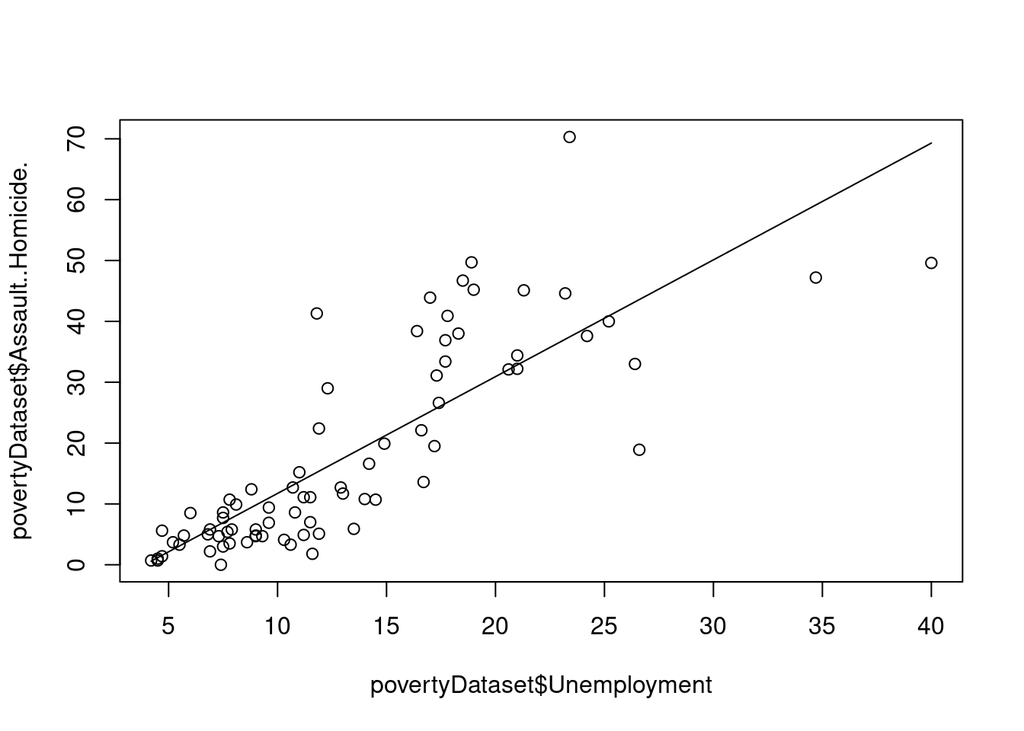

```r
fit.AssaultUnemployment <- lm(Assault..Homicide.~Unemployment,data=povertyDataset)
plot(povertyDataset$Unemployment, povertyDataset$Assault..Homicide.)
lines(povertyDataset$Unemployment, fit.AssaultUnemployment$fitted.values)
```

```r
summary(fit.AssaultUnemployment)
```

```
##
## Call:
## lm(formula = Assault..Homicide. ~ Unemployment, data = povertyDataset)
##
## Residuals:
##     Min      1Q  Median      3Q     Max
## -24.684  -5.110  -0.898   2.974  32.856
##
## Coefficients:
##              Estimate Std. Error t value Pr(>|t|)
## (Intercept)   -7.4617     2.3689   -3.15  0.00235 **
## Unemployment   1.9190     0.1576   12.17  < 2e-16 ***
## ---
## Signif. codes:  0 '***' 0.001 '**' 0.01 '*' 0.05 '.' 0.1 ' ' 1
##
## Residual standard error: 9.664 on 75 degrees of freedom
## Multiple R-squared:  0.664,  Adjusted R-squared:  0.6595
## F-statistic: 148.2 on 1 and 75 DF,  p-value: < 2.2e-16
```

```r
ks.test(rstandard(fit.AssaultUnemployment), 'pnorm')
```

```
##
##  One-sample Kolmogorov-Smirnov test
##
## data:  rstandard(fit.AssaultUnemployment)
## D = 0.16491, p-value = 0.0268
## alternative hypothesis: two-sided
```

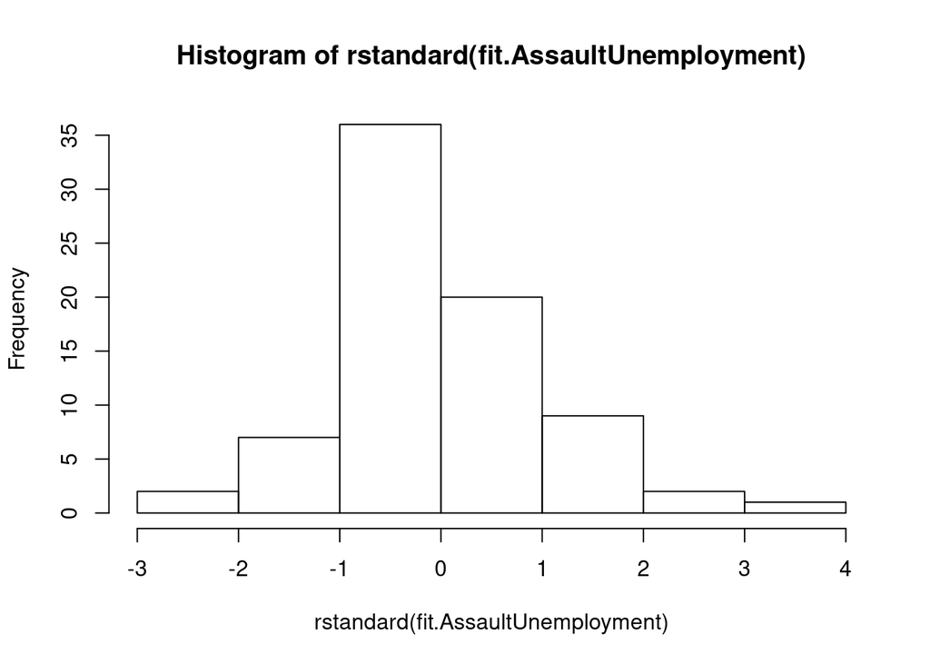

```r
hist(rstandard(fit.AssaultUnemployment))
```

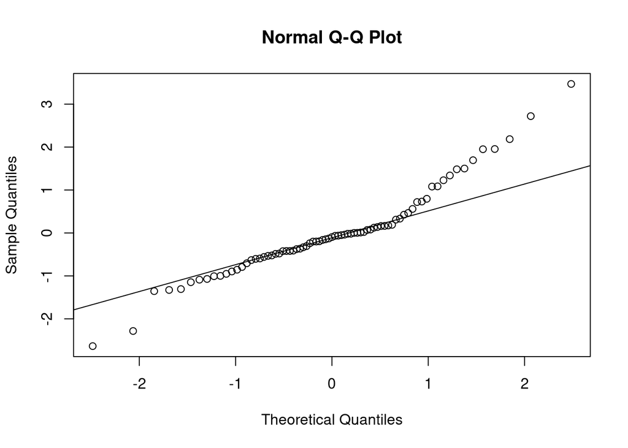

```r
qqnorm(rstandard(fit.AssaultUnemployment))
qqline(rstandard(fit.AssaultUnemployment))
```

Onda s nezaposlenošću procjenjujemo i Firearm related.

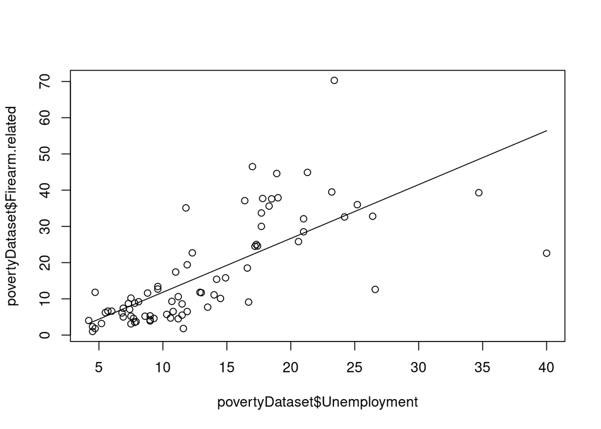

```r
fit.FirearmUnemployment <- lm(Firearm.related~Unemployment,data=povertyDataset)
plot(povertyDataset$Unemployment, povertyDataset$Firearm.related)
lines(povertyDataset$Unemployment, fit.FirearmUnemployment$fitted.values)
```

```r
summary(fit.FirearmUnemployment)
```

```
##
## Call:
## lm(formula = Firearm.related ~ Unemployment, data = povertyDataset)
##
## Residuals:
##     Min      1Q  Median      3Q     Max
## -33.804  -5.035  -1.348   2.173  38.565
##
## Coefficients:
##              Estimate Std. Error t value Pr(>|t|)
## (Intercept)   -3.0395     2.4669  -1.232    0.222
## Unemployment   1.4861     0.1642   9.052 1.18e-13 ***
## ---
## Signif. codes:  0 '***' 0.001 '**' 0.01 '*' 0.05 '.' 0.1 ' ' 1
##
## Residual standard error: 10.06 on 75 degrees of freedom
## Multiple R-squared:  0.5221, Adjusted R-squared:  0.5157
## F-statistic: 81.94 on 1 and 75 DF,  p-value: 1.185e-13
```

```r
ks.test(rstandard(fit.FirearmUnemployment), 'pnorm')
```

```
##
##  One-sample Kolmogorov-Smirnov test
##
## data:  rstandard(fit.FirearmUnemployment)
## D = 0.17389, p-value = 0.0166
## alternative hypothesis: two-sided
```

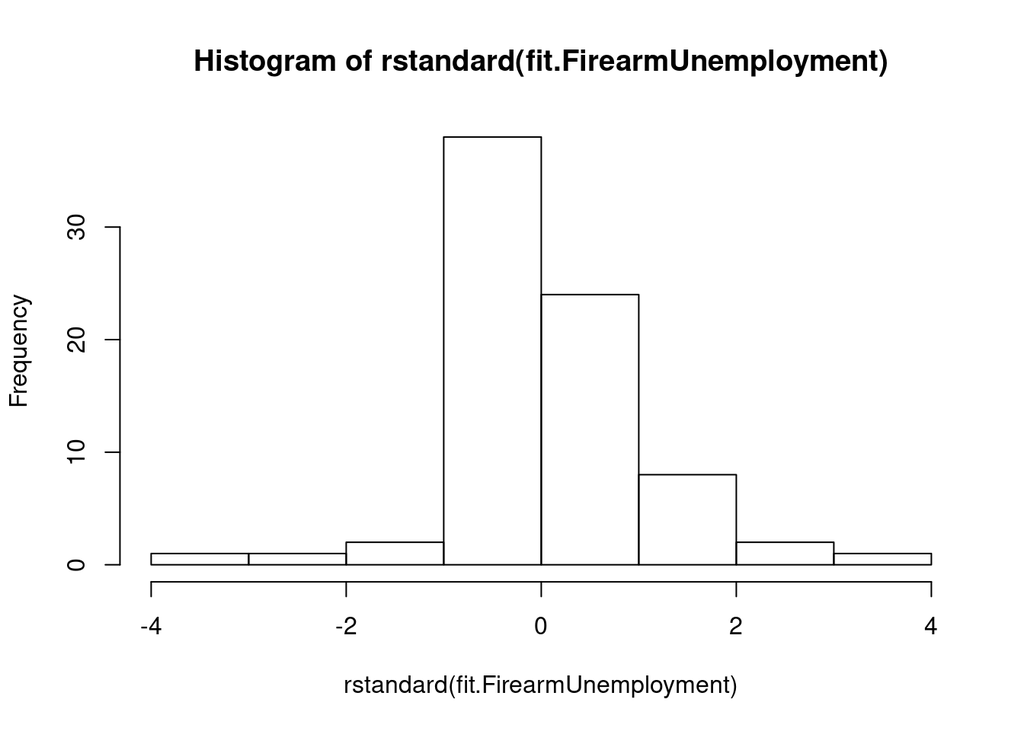

```r
hist(rstandard(fit.FirearmUnemployment))
```

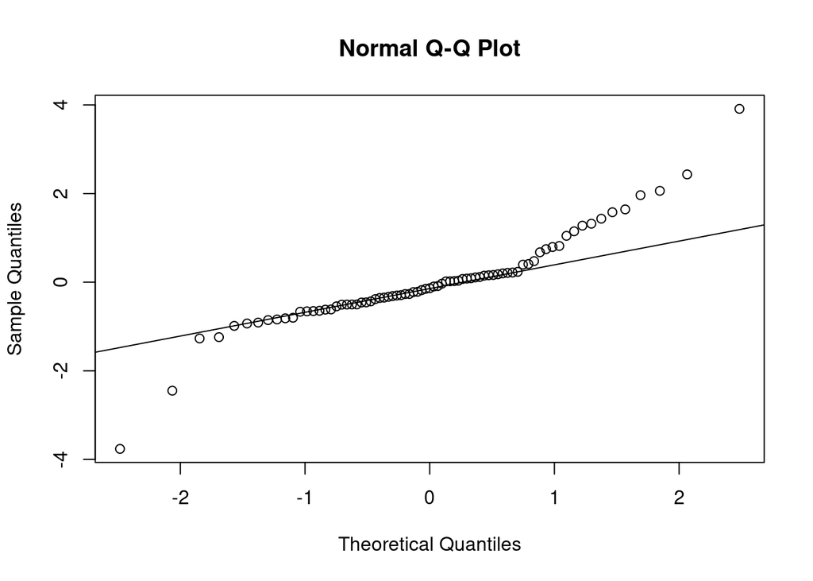

```r
qqnorm(rstandard(fit.FirearmUnemployment))
qqline(rstandard(fit.FirearmUnemployment))
```

Sada koristimo varijablu No High School Diploma. Uočavamo da reziduali nisu ni približno distribuirani po normalnoj distribuciji te je pretpostavka linearne regresije narušena što možda upućuje da nam treba neki složeniji model.

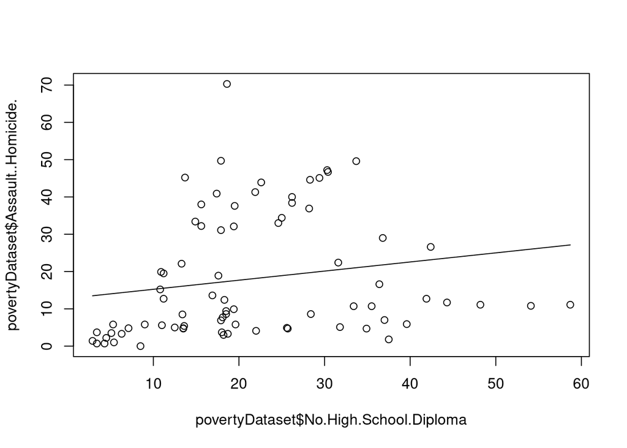

```r
fit.AssaultDiploma <- lm(Assault..Homicide.
                         ~No.High.School.Diploma,data=povertyDataset)
plot(povertyDataset$No.High.School.Diploma, povertyDataset$Assault..Homicide.)
lines(povertyDataset$No.High.School.Diploma, fit.AssaultDiploma$fitted.values)
```

```r
summary(fit.AssaultDiploma)
```

```
##
## Call:
## lm(formula = Assault..Homicide. ~ No.High.School.Diploma, data = povertyDataset)
##
## Residuals:
##     Min      1Q  Median      3Q     Max
## -20.154 -11.916  -8.712  14.568  52.963
##
## Coefficients:
##                        Estimate Std. Error t value Pr(>|t|)
## (Intercept)             12.7925     3.7804   3.384  0.00114 **
## No.High.School.Diploma   0.2443     0.1522   1.605  0.11262
## ---
## Signif. codes:  0 '***' 0.001 '**' 0.01 '*' 0.05 '.' 0.1 ' ' 1
##
## Residual standard error: 16.39 on 75 degrees of freedom
## Multiple R-squared:  0.03322,    Adjusted R-squared:  0.02033
## F-statistic: 2.577 on 1 and 75 DF,  p-value: 0.1126
```

```r
ks.test(rstandard(fit.AssaultDiploma), 'pnorm')
```

```
##
##  One-sample Kolmogorov-Smirnov test
##
## data:  rstandard(fit.AssaultDiploma)
## D = 0.23783, p-value = 0.0002572
## alternative hypothesis: two-sided
```

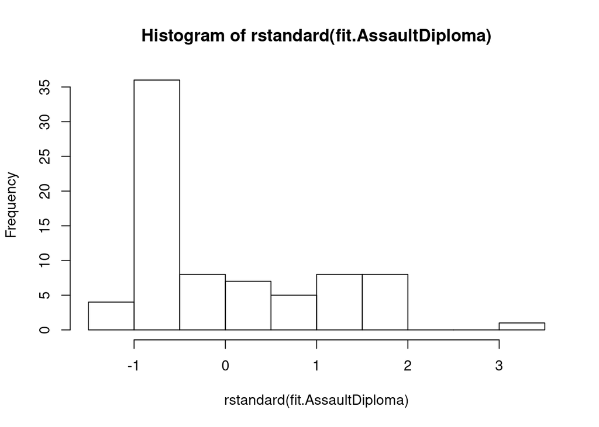

```r
hist(rstandard(fit.AssaultDiploma))
```

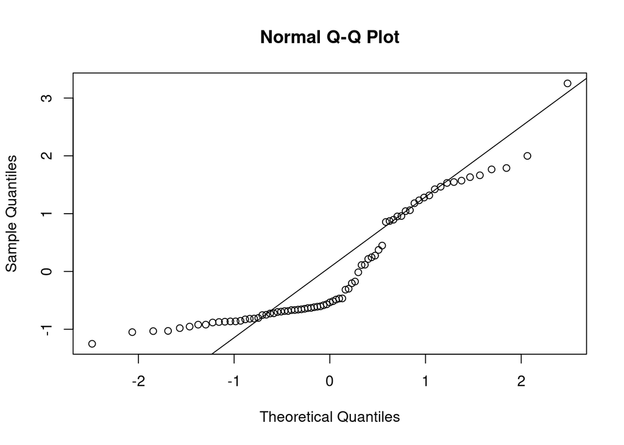

```r
qqnorm(rstandard(fit.AssaultDiploma))
qqline(rstandard(fit.AssaultDiploma))
```

Ako koristimo polinomijalnu regresiju dobivamo puno bolje rezultate

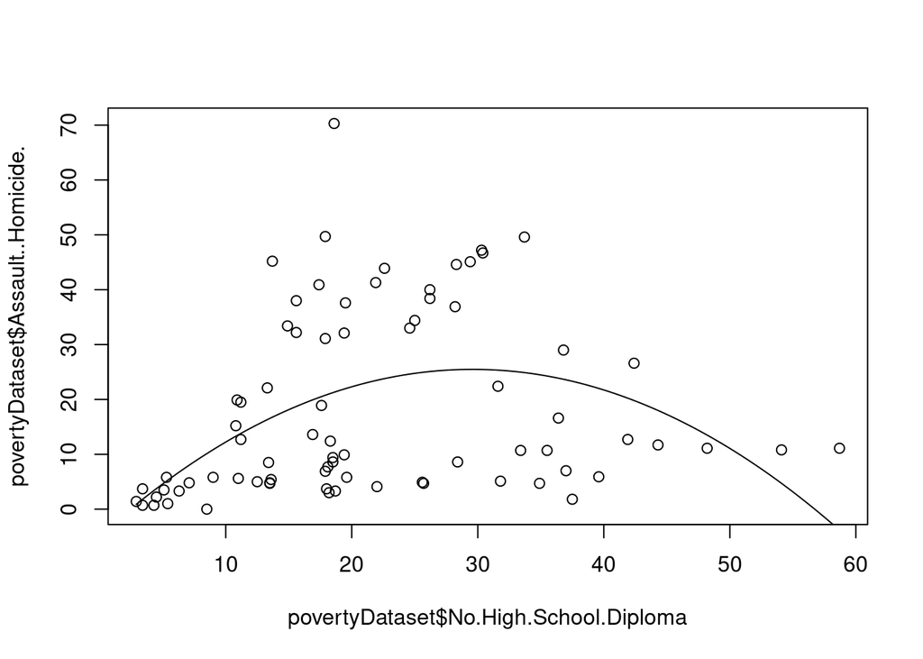

```r
fit.AssaultDiplomaSq <- lm(Assault..Homicide.~No.High.School.Diploma+
                         I(No.High.School.Diploma^2),data=povertyDataset)

plot(povertyDataset$No.High.School.Diploma, povertyDataset$Assault..Homicide.)
curve(predict(fit.AssaultDiplomaSq,
              newdata=data.frame(No.High.School.Diploma=x)),add=T)
```

```r
summary(fit.AssaultDiplomaSq)
```

```
##
## Call:
## lm(formula = Assault..Homicide. ~ No.High.School.Diploma + I(No.High.School.Diploma^2),
##     data = povertyDataset)
##
## Residuals:
##     Min      1Q  Median      3Q     Max
## -21.512 -11.842  -2.399  10.336  48.988
##
## Coefficients:
##                              Estimate Std. Error t value Pr(>|t|)
## (Intercept)                 -4.761998   5.634127  -0.845 0.400720
## No.High.School.Diploma       2.044636   0.476875   4.288 5.38e-05 ***
## I(No.High.School.Diploma^2) -0.034560   0.008755  -3.947 0.000178 ***
## ---
## Signif. codes:  0 '***' 0.001 '**' 0.01 '*' 0.05 '.' 0.1 ' ' 1
##
## Residual standard error: 15 on 74 degrees of freedom
## Multiple R-squared:  0.2014, Adjusted R-squared:  0.1798
## F-statistic:  9.33 on 2 and 74 DF,  p-value: 0.0002436
```

```r
ks.test(rstandard(fit.AssaultDiplomaSq), "pnorm")
```

```
##
##  One-sample Kolmogorov-Smirnov test
##
## data:  rstandard(fit.AssaultDiplomaSq)
## D = 0.10108, p-value = 0.3853
## alternative hypothesis: two-sided
```

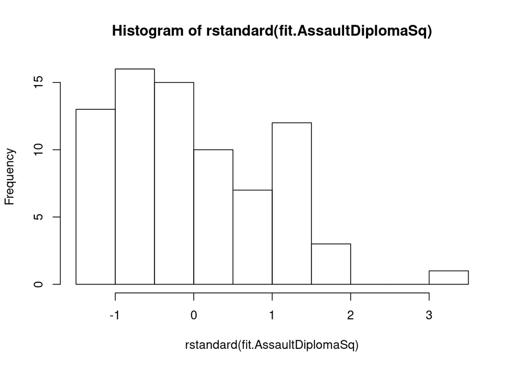

```r
hist(rstandard(fit.AssaultDiplomaSq))
```

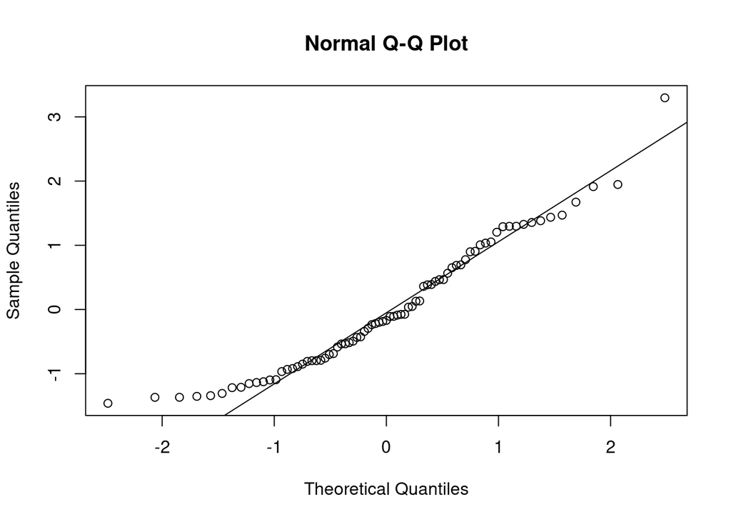

```r
qqnorm(rstandard(fit.AssaultDiplomaSq))
qqline(rstandard(fit.AssaultDiplomaSq))
```

Korištenjem dohodka po glavi dobivamo ne toliko dobar model, ali iz grafa možemo uočiti koliko ima manje zločina u prosječno bogatijim kvartovima.

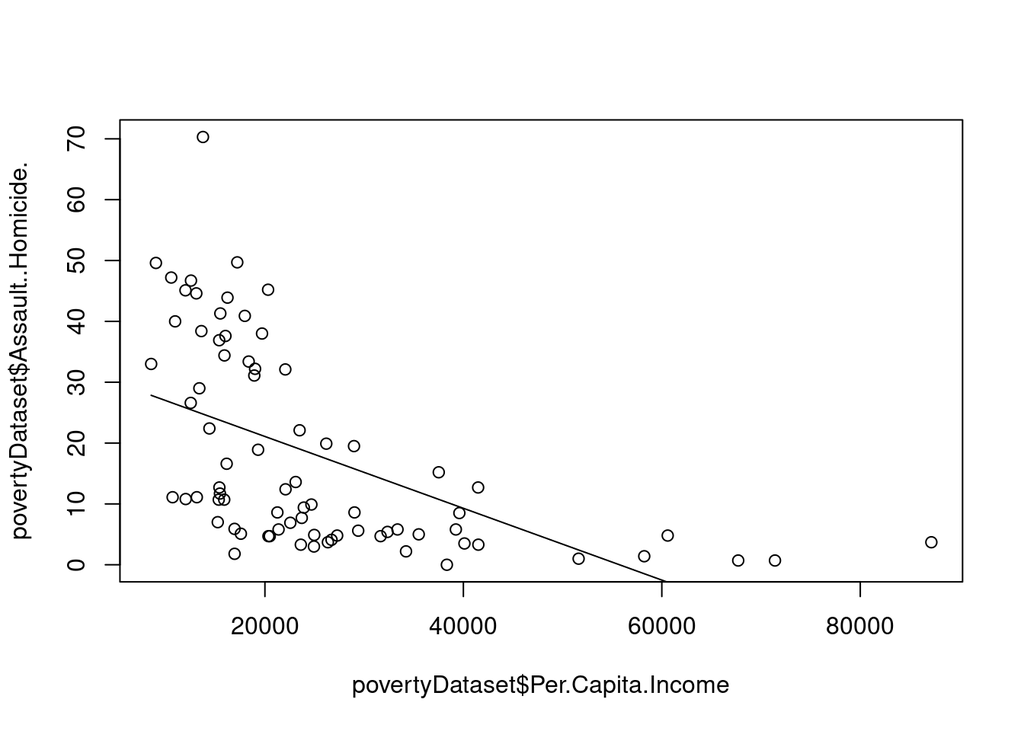

```r
fit.AssaultIncome <- lm(Assault..Homicide.~Per.Capita.Income,data=povertyDataset)
plot(povertyDataset$Per.Capita.Income, povertyDataset$Assault..Homicide.)
lines(povertyDataset$Per.Capita.Income, fit.AssaultIncome$fitted.values)
```

```r
summary(fit.AssaultIncome)
```

```
##
## Call:
## lm(formula = Assault..Homicide. ~ Per.Capita.Income, data = povertyDataset)
##
## Residuals:
##     Min      1Q  Median      3Q     Max
## -21.087 -11.986  -3.928  10.910  45.534
##
## Coefficients:
##                     Estimate Std. Error t value Pr(>|t|)
## (Intercept)       32.8833950  3.1573233  10.415 3.19e-16 ***
## Per.Capita.Income -0.0005901  0.0001082  -5.452 6.11e-07 ***
## ---
## Signif. codes:  0 '***' 0.001 '**' 0.01 '*' 0.05 '.' 0.1 ' ' 1
##
## Residual standard error: 14.11 on 75 degrees of freedom
## Multiple R-squared:  0.2838, Adjusted R-squared:  0.2743
## F-statistic: 29.72 on 1 and 75 DF,  p-value: 6.114e-07
```

```r
ks.test(rstandard(fit.AssaultIncome), 'pnorm')
```

```
##
##  One-sample Kolmogorov-Smirnov test
##
## data:  rstandard(fit.AssaultIncome)
## D = 0.14008, p-value = 0.0883
## alternative hypothesis: two-sided
```

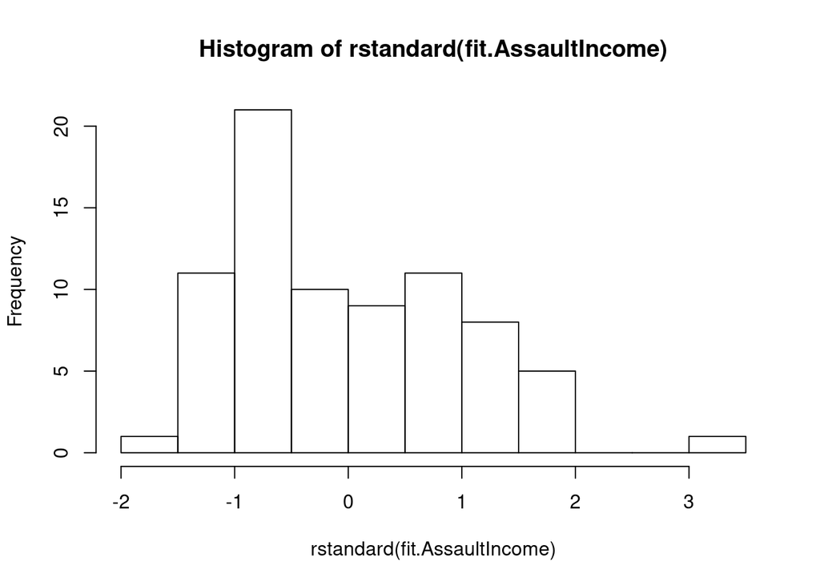

```r
hist(rstandard(fit.AssaultIncome))
```

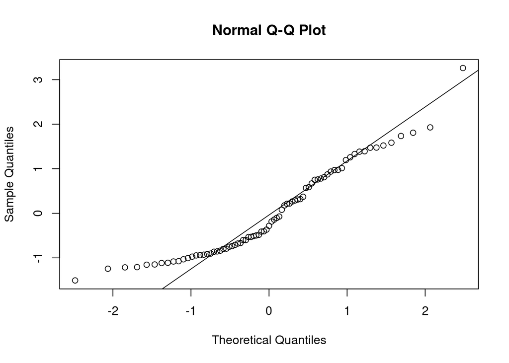

```r
qqnorm(rstandard(fit.AssaultIncome))
qqline(rstandard(fit.AssaultIncome))
```

Primjenom transformacije logaritmom nad ulaznim podacima Per Capita Income dobivamo puno bolji rezultat.

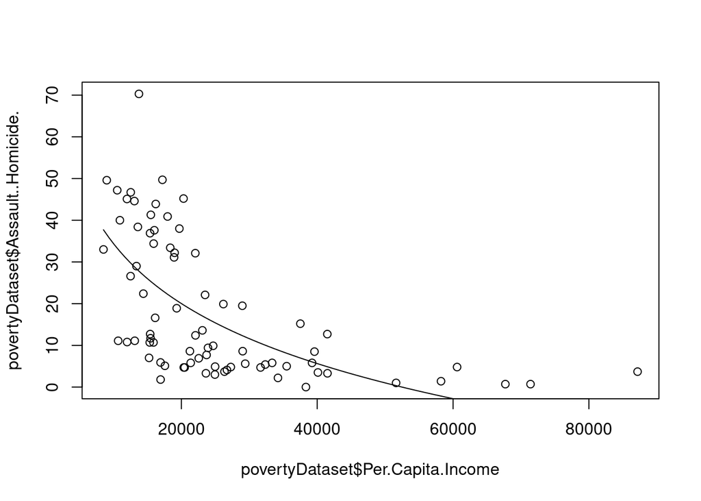

```r
fit.AssaultIncome <- lm(Assault..Homicide.~log(Per.Capita.Income),data=povertyDataset)
plot(povertyDataset$Per.Capita.Income, povertyDataset$Assault..Homicide.)
curve(predict(fit.AssaultIncome,
              newdata=data.frame(Per.Capita.Income=x)),add=T)
```

```r
summary(fit.AssaultIncome)
```

```
##
## Call:
## lm(formula = Assault..Homicide. ~ log(Per.Capita.Income), data = povertyDataset)
##
## Residuals:
##     Min      1Q  Median      3Q     Max
## -21.918 -10.160  -3.111   9.930  42.504
##
## Coefficients:
##                        Estimate Std. Error t value Pr(>|t|)
## (Intercept)             225.645     30.203   7.471 1.20e-10 ***
## log(Per.Capita.Income)  -20.762      3.017  -6.881 1.55e-09 ***
## ---
## Signif. codes:  0 '***' 0.001 '**' 0.01 '*' 0.05 '.' 0.1 ' ' 1
##
## Residual standard error: 13.05 on 75 degrees of freedom
## Multiple R-squared:  0.387,  Adjusted R-squared:  0.3788
## F-statistic: 47.35 on 1 and 75 DF,  p-value: 1.55e-09
```

```r
ks.test(rstandard(fit.AssaultIncome), 'pnorm')
```

```
##
##  One-sample Kolmogorov-Smirnov test
##
## data:  rstandard(fit.AssaultIncome)
## D = 0.10187, p-value = 0.3759
## alternative hypothesis: two-sided
```

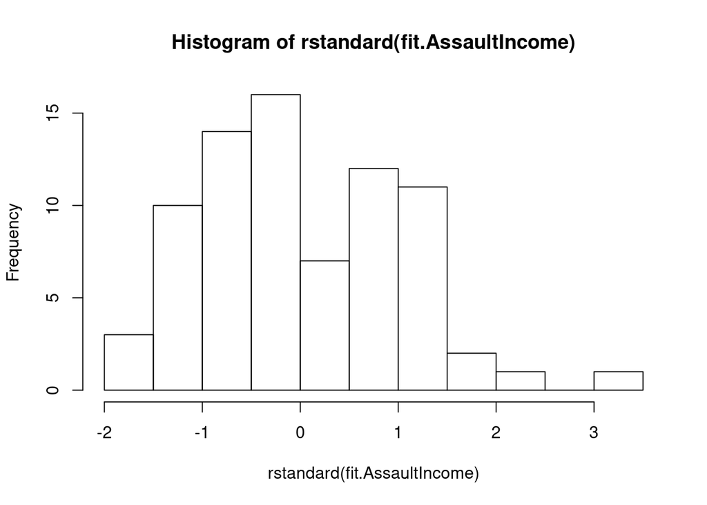

```r
hist(rstandard(fit.AssaultIncome))
```

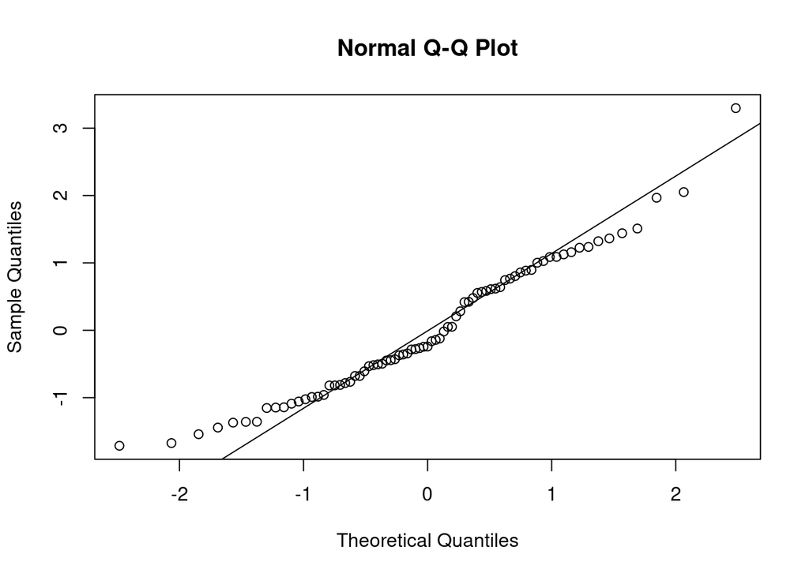

```r
qqnorm(rstandard(fit.AssaultIncome))
qqline(rstandard(fit.AssaultIncome))
```

## Višestruka regresija

Prije procjene modela višestruke regresije trebamo provjeriti jesu li varijable međusobno zavisne. Ako nemaju vrlo visoku korelaciju možemo ih koristiti zajedno u modeliranju. Već smo pokazali neke varijable koje imaju veliku korelaciju.

Kao što smo mogli očekivati nezaposlenost i siromaštvo objašnjavaju iste efekte u podacima te nećemo dobiti puno bolji model nego samo sa korištenjem siromaštva.

```r
fit1 <- lm(povertyDataset$Assault..Homicide.~povertyDataset$Unemployment +
             povertyDataset$Below.Poverty.Level)
summary(fit1)
```

```
##
## Call:
## lm(formula = povertyDataset$Assault..Homicide. ~ povertyDataset$Unemployment +
##     povertyDataset$Below.Poverty.Level)
##
## Residuals:
##     Min      1Q  Median      3Q     Max
## -24.871  -4.487  -0.780   2.902  34.466
##
## Coefficients:
##                                    Estimate Std. Error t value Pr(>|t|)
## (Intercept)                         -8.0310     2.4306  -3.304  0.00147 **
## povertyDataset$Unemployment          1.7258     0.2441   7.069  7.3e-10 ***
## povertyDataset$Below.Poverty.Level   0.1548     0.1493   1.036  0.30334
## ---
## Signif. codes:  0 '***' 0.001 '**' 0.01 '*' 0.05 '.' 0.1 ' ' 1
##
## Residual standard error: 9.659 on 74 degrees of freedom
## Multiple R-squared:  0.6688, Adjusted R-squared:  0.6598
## F-statistic:  74.7 on 2 and 74 DF,  p-value: < 2.2e-16
```

Kada smo uključili logaritmom transformirani Per Capita Income i samo Per Capita Income dobili smo bolji model nego samo s logaritmom transformiranim. Nismo sigurni zašto je to tako. Uključivanjem više varijabli, a pogotovo log(Per Capita Income) Unemployment varijabla je gubila na značajnosti za model.

```r
fit2 <- lm(povertyDataset$Assault..Homicide.~povertyDataset$Unemployment +
             povertyDataset$No.High.School.Diploma
           + log(povertyDataset$Per.Capita.Income)
           + povertyDataset$Per.Capita.Income + exp(povertyDataset$Dependency))
summary(fit2)
```

```
##
## Call:
## lm(formula = povertyDataset$Assault..Homicide. ~ povertyDataset$Unemployment +
##     povertyDataset$No.High.School.Diploma + log(povertyDataset$Per.Capita.Income) +
##     povertyDataset$Per.Capita.Income + exp(povertyDataset$Dependency))
##
## Residuals:
##      Min       1Q   Median       3Q      Max
## -16.3658  -4.5086  -0.1477   3.5721  21.5639
##
## Coefficients:
##                                         Estimate Std. Error t value Pr(>|t|)
## (Intercept)                            7.173e+02  1.078e+02   6.656 4.99e-09
## povertyDataset$Unemployment            5.956e-01  2.399e-01   2.483   0.0154
## povertyDataset$No.High.School.Diploma -1.152e+00  1.615e-01  -7.135 6.64e-10
## log(povertyDataset$Per.Capita.Income) -7.097e+01  1.077e+01  -6.589 6.59e-09
## povertyDataset$Per.Capita.Income       1.106e-03  2.312e-04   4.783 9.07e-06
## exp(povertyDataset$Dependency)        -6.109e-21  1.368e-21  -4.467 2.92e-05
##
## (Intercept)                           ***
## povertyDataset$Unemployment           *
## povertyDataset$No.High.School.Diploma ***
## log(povertyDataset$Per.Capita.Income) ***
## povertyDataset$Per.Capita.Income      ***
## exp(povertyDataset$Dependency)        ***
## ---
## Signif. codes:  0 '***' 0.001 '**' 0.01 '*' 0.05 '.' 0.1 ' ' 1
##
## Residual standard error: 7.423 on 71 degrees of freedom
## Multiple R-squared:  0.8123, Adjusted R-squared:  0.7991
## F-statistic: 61.45 on 5 and 71 DF,  p-value: < 2.2e-16
```

Za Firearm Related najbolji smo model dobili bez uključivanja Unemployment. Iz same korelacijske tablice vidimo da je Assault Homicide općenito više korelirana s ostalim varijablama nego Firearm Related.

```r
fit3 <- lm(povertyDataset$Firearm.related~
             povertyDataset$No.High.School.Diploma
           + log(povertyDataset$Per.Capita.Income)
           + povertyDataset$Per.Capita.Income + exp(povertyDataset$Dependency))
summary(fit3)
```

```
##
## Call:
## lm(formula = povertyDataset$Firearm.related ~ povertyDataset$No.High.School.Diploma +
##     log(povertyDataset$Per.Capita.Income) + povertyDataset$Per.Capita.Income +
##     exp(povertyDataset$Dependency))
##
## Residuals:
##      Min       1Q   Median       3Q      Max
## -27.0867  -5.0575  -0.0375   3.9814  27.6317
##
## Coefficients:
##                                         Estimate Std. Error t value Pr(>|t|)
## (Intercept)                            7.363e+02  7.440e+01   9.897 4.57e-15
## povertyDataset$No.High.School.Diploma -1.220e+00  1.315e-01  -9.277 6.38e-14
## log(povertyDataset$Per.Capita.Income) -7.191e+01  7.750e+00  -9.279 6.33e-14
## povertyDataset$Per.Capita.Income       1.041e-03  2.150e-04   4.844 7.07e-06
## exp(povertyDataset$Dependency)        -4.958e-21  1.445e-21  -3.432 0.000996
##
## (Intercept)                           ***
## povertyDataset$No.High.School.Diploma ***
## log(povertyDataset$Per.Capita.Income) ***
## povertyDataset$Per.Capita.Income      ***
## exp(povertyDataset$Dependency)        ***
## ---
## Signif. codes:  0 '***' 0.001 '**' 0.01 '*' 0.05 '.' 0.1 ' ' 1
##
## Residual standard error: 8.113 on 72 degrees of freedom
## Multiple R-squared:  0.7019, Adjusted R-squared:  0.6853
## F-statistic: 42.38 on 4 and 72 DF,  p-value: < 2.2e-16
```